# **Advanced Data Science Capstone: Automated Image Processing for Breast Tumor Biopsies**

Author: Fernando M. Delgado Chaves

## 1. Introduction

## Wisconsin Breast Cancer Dataset

> Street, W. N., Wolberg, W. H., & Mangasarian, O. L. (1993, July). Nuclear feature extraction for breast tumor diagnosis. In Biomedical image processing and biomedical visualization (Vol. 1905, pp. 861-870). International Society for Optics and Photonics. https://www.kaggle.com/uciml/breast-cancer-wisconsin-data

The 1993 Street et al. Breast Cancer Wisconsin (Diagnostic) Data Set collects information from 569 breast tumor biopsies, of which 357 are benign and 212 are malignant. The biopsies were obtained by fine needle aspiration. A small portion of the tumor tissue is then placed on a slide and stained for imaging. With an interactive system, an outline is established near the limits of individual cell nuclei. These contours are deformed to fit the exact morphology of the nuclei, thus allowing for precise and automated analysis of the size, shape, and texture of the nuclei. An example of this segmentation is shown below:

[figure not shown]

The parameters/features analyzed in each sample/instance are the following:

1. Radius: The radius of an individual nucleus is measured by averaging the length of the segments defined by the centroid of the contour and the individual points that draw the contour.
2. Texture: For a grayscale image, the pixel value is a single number that represents the brightness of the pixel. The texture of the cell's core is measured by finding the variation of the grayscale intensities in the component pixels.
3. Perimeter: The total distance formed by the contour points constitutes the nuclear perimeter.
4. Area: The nuclear area is measured by counting the number of pixels inside the outline and adding half of the perimeter pixels.
5. Smoothness: The smoothness of a nuclear contour is quantified by measuring the difference between the length of a radial line and the average length of the rest of the radial lines. An example can be seen in the Figure below:
1. Compactness: Perimeter and area are combined to give a measure of the compactness of the cell nuclei using the formula perimeter$^{2}$ / area - 1.0. This dimensionless number is minimal for a circular disc and increases with the irregularity of the boundary. However, this shape measure also increases for elongated cell nuclei, which do not necessarily indicate a higher probability of malignancy. The characteristic is also biased for small cells due to the decrease in precision imposed by the digitization of the sample.
2. Concavity: The mean of the severity of the concavities or clefts in the nucleus of a cell. Segments are drawn between non-adjacent nuclear boundary points and the degree to which the actual boundary of the nucleus is within each string is measured. An example is shown in the Figure below. This parameter is greatly affected by the length of these segments, as smaller segments better capture small concavities. This measure emphasizes the small slits, as larger morphological irregularities are captured by other features.
1. Concave points: average for the number of concave portions of the contour. This characteristic is similar to that of concavity, but measures only the number, rather than the degree of concavity.
2. Symmetry: To measure symmetry, the major axis, or the longest segment that passes through the center, is found. Then the difference in length between the lines perpendicular to the major axis is measured up to the cell boundary in both directions. An example can be seen in the Figure below:
1. Fractal dimension: The fractal dimension of a cell is approximated using the 'coastal approximation'. The perimeter of the nucleus is measured with increasingly large 'rules'. As the size of the ruler increases, decreasing the accuracy of the measurement, the observed perimeter decreases. An example can be seen in Figure below. Plotting these values on a recording scale and measuring the downward slope is an approximation of the fractal dimension. As with all characteristics of the shape, a higher value corresponds to a less regular contour and therefore a higher probability of malignancy.

[figure not shown]

# 2. Results

## 2.1 Initial Data Exploration

The downloaded diagnostic dataset was imported. First, the *id* attribute was removed, as it does not provide any information beyond the identifier of each sample. Another attribute, probably imported by mistake, called *Unnamed 32* was also removed.

```python
import numpy as np # linear algebra
import pandas as pd # data processing, CSV file I/O (e.g. pd.read_csv)
import seaborn as sns # data visualization library
import matplotlib.pyplot as plt
#https://jupyterlab-9.labs.cognitiveclass.ai/hub/user-redirect/lab/tree/labs/User/Advanced%20IBM%20Data%20Science%20/Capstone/data.csv
data_raw = pd.read_csv('data.csv')
data = data_raw.drop(['id', 'Unnamed: 32'], axis=1)
data.head()
```

|  | diagnosis | radius_mean | texture_mean | perimeter_mean | area_mean | smoothness_mean | compactness_mean | concavity_mean | concave points_mean | symmetry_mean | ... | radius_worst | texture_worst | perimeter_worst | area_worst | smoothness_worst | compactness_worst | concavity_worst | concave points_worst | symmetry_worst | fractal_dimension_worst |
| --- | --- | --- | --- | --- | --- | --- | --- | --- | --- | --- | --- | --- | --- | --- | --- | --- | --- | --- | --- | --- | --- |
| 0 | M | 17.99 | 10.38 | 122.80 | 1001.0 | 0.11840 | 0.27760 | 0.3001 | 0.14710 | 0.2419 | ... | 25.38 | 17.33 | 184.60 | 2019.0 | 0.1622 | 0.6656 | 0.7119 | 0.2654 | 0.4601 | 0.11890 |
| 1 | M | 20.57 | 17.77 | 132.90 | 1326.0 | 0.08474 | 0.07864 | 0.0869 | 0.07017 | 0.1812 | ... | 24.99 | 23.41 | 158.80 | 1956.0 | 0.1238 | 0.1866 | 0.2416 | 0.1860 | 0.2750 | 0.08902 |
| 2 | M | 19.69 | 21.25 | 130.00 | 1203.0 | 0.10960 | 0.15990 | 0.1974 | 0.12790 | 0.2069 | ... | 23.57 | 25.53 | 152.50 | 1709.0 | 0.1444 | 0.4245 | 0.4504 | 0.2430 | 0.3613 | 0.08758 |
| 3 | M | 11.42 | 20.38 | 77.58 | 386.1 | 0.14250 | 0.28390 | 0.2414 | 0.10520 | 0.2597 | ... | 14.91 | 26.50 | 98.87 | 567.7 | 0.2098 | 0.8663 | 0.6869 | 0.2575 | 0.6638 | 0.17300 |
| 4 | M | 20.29 | 14.34 | 135.10 | 1297.0 | 0.10030 | 0.13280 | 0.1980 | 0.10430 | 0.1809 | ... | 22.54 | 16.67 | 152.20 | 1575.0 | 0.1374 | 0.2050 | 0.4000 | 0.1625 | 0.2364 | 0.07678 |

5 rows × 31 columns

```python
data.isna().sum().sum()
```

```
0
```

```python
data.dtypes
```

```
diagnosis                   object
radius_mean                float64
texture_mean               float64
perimeter_mean             float64
area_mean                  float64
smoothness_mean            float64
compactness_mean           float64
concavity_mean             float64
concave points_mean        float64
symmetry_mean              float64
fractal_dimension_mean     float64
radius_se                  float64
texture_se                 float64
perimeter_se               float64
area_se                    float64
smoothness_se              float64
compactness_se             float64
concavity_se               float64
concave points_se          float64
symmetry_se                float64
fractal_dimension_se       float64
radius_worst               float64
texture_worst              float64
perimeter_worst            float64
area_worst                 float64
smoothness_worst           float64
compactness_worst          float64
concavity_worst            float64
concave points_worst       float64
symmetry_worst             float64
fractal_dimension_worst    float64
dtype: object
```

```python
data.diagnosis.value_counts()
```

```
B    357
M    212
Name: diagnosis, dtype: int64
```

```python
pd.set_option('display.max_columns', None)
pd.set_option('display.max_rows', None)
data.groupby('diagnosis').describe()
```

| diagnosis | radius_mean count | radius_mean mean | radius_mean std | radius_mean min | radius_mean 25% | radius_mean 50% | radius_mean 75% | radius_mean max | texture_mean count | texture_mean mean | texture_mean std | texture_mean min | texture_mean 25% | texture_mean 50% | texture_mean 75% | texture_mean max | perimeter_mean count | perimeter_mean mean | perimeter_mean std | perimeter_mean min | perimeter_mean 25% | perimeter_mean 50% | perimeter_mean 75% | perimeter_mean max | area_mean count | area_mean mean | area_mean std | area_mean min | area_mean 25% | … |
| --- | --- | --- | --- | --- | --- | --- | --- | --- | --- | --- | --- | --- | --- | --- | --- | --- | --- | --- | --- | --- | --- | --- | --- | --- | --- | --- | --- | --- | --- | --- |
| B | 357.0 | 12.146524 | 1.780512 | 6.981 | 11.080 | 12.200 | 13.37 | 17.85 | 357.0 | 17.914762 | 3.995125 | 9.71 | 15.1500 | 17.39 | 19.760 | 33.81 | 357.0 | 78.075406 | 11.807438 | 43.79 | 70.870 | 78.18 | 86.100 | 114.6 | 357.0 | 462.790196 | 134.287118 | 143.5 | 378.2 | … |
| M | 212.0 | 17.462830 | 3.203971 | 10.950 | 15.075 | 17.325 | 19.59 | 28.11 | 212.0 | 21.604906 | 3.779470 | 10.38 | 19.3275 | 21.46 | 23.765 | 39.28 | 212.0 | 115.365377 | 21.854653 | 71.90 | 98.745 | 114.20 | 129.925 | 188.5 | 212.0 | 978.376415 | 367.937978 | 361.6 | 705.3 | … |

By just looking at the mean, differences are observed between benign and malign samples for multiple features. We can plot this differences in a box plot. For this, data was normalized for improved visualization.

```python
label = data.diagnosis
unlabeled_data = data.drop(['diagnosis'],axis = 1 )
```

```python
from sklearn import preprocessing

x = unlabeled_data.values #returns a numpy array
min_max_scaler = preprocessing.MinMaxScaler()
x_scaled = min_max_scaler.fit_transform(x)
unlabeled_data_scaled = pd.DataFrame(x_scaled)
unlabeled_data_scaled.columns = unlabeled_data.columns
unlabeled_data_scaled = pd.concat([label, unlabeled_data_scaled], axis=1)
unlabeled_data_scaled.head()
```

|  | diagnosis | radius_mean | texture_mean | perimeter_mean | area_mean | smoothness_mean | compactness_mean | concavity_mean | concave points_mean | symmetry_mean | fractal_dimension_mean | radius_se | texture_se | perimeter_se | area_se | smoothness_se | compactness_se | concavity_se | concave points_se | symmetry_se | fractal_dimension_se | radius_worst | texture_worst | perimeter_worst | area_worst | smoothness_worst | compactness_worst | concavity_worst | concave points_worst | … |
| --- | --- | --- | --- | --- | --- | --- | --- | --- | --- | --- | --- | --- | --- | --- | --- | --- | --- | --- | --- | --- | --- | --- | --- | --- | --- | --- | --- | --- | --- | --- |
| 0 | M | 0.521037 | 0.022658 | 0.545989 | 0.363733 | 0.593753 | 0.792037 | 0.703140 | 0.731113 | 0.686364 | 0.605518 | 0.356147 | 0.120469 | 0.369034 | 0.273811 | 0.159296 | 0.351398 | 0.135682 | 0.300625 | 0.311645 | 0.183042 | 0.620776 | 0.141525 | 0.668310 | 0.450698 | 0.601136 | 0.619292 | 0.568610 | 0.912027 | … |
| 1 | M | 0.643144 | 0.272574 | 0.615783 | 0.501591 | 0.289880 | 0.181768 | 0.203608 | 0.348757 | 0.379798 | 0.141323 | 0.156437 | 0.082589 | 0.124440 | 0.125660 | 0.119387 | 0.081323 | 0.046970 | 0.253836 | 0.084539 | 0.091110 | 0.606901 | 0.303571 | 0.539818 | 0.435214 | 0.347553 | 0.154563 | 0.192971 | 0.639175 | … |
| 2 | M | 0.601496 | 0.390260 | 0.595743 | 0.449417 | 0.514309 | 0.431017 | 0.462512 | 0.635686 | 0.509596 | 0.211247 | 0.229622 | 0.094303 | 0.180370 | 0.162922 | 0.150831 | 0.283955 | 0.096768 | 0.389847 | 0.205690 | 0.127006 | 0.556386 | 0.360075 | 0.508442 | 0.374508 | 0.483590 | 0.385375 | 0.359744 | 0.835052 | … |
| 3 | M | 0.210090 | 0.360839 | 0.233501 | 0.102906 | 0.811321 | 0.811361 | 0.565604 | 0.522863 | 0.776263 | 1.000000 | 0.139091 | 0.175875 | 0.126655 | 0.038155 | 0.251453 | 0.543215 | 0.142955 | 0.353665 | 0.728148 | 0.287205 | 0.248310 | 0.385928 | 0.241347 | 0.094008 | 0.915472 | 0.814012 | 0.548642 | 0.884880 | … |
| 4 | M | 0.629893 | 0.156578 | 0.630986 | 0.489290 | 0.430351 | 0.347893 | 0.463918 | 0.518390 | 0.378283 | 0.186816 | 0.233822 | 0.093065 | 0.220563 | 0.163688 | 0.332359 | 0.167918 | 0.143636 | 0.357075 | 0.136179 | 0.145800 | 0.519744 | 0.123934 | 0.506948 | 0.341575 | 0.437364 | 0.172415 | 0.319489 | 0.558419 | … |

```
(array([ 0,  1,  2,  3,  4,  5,  6,  7,  8,  9, 10, 11, 12, 13, 14, 15, 16,
        17, 18, 19, 20, 21, 22, 23, 24, 25, 26, 27, 28, 29]),
 [Text(0, 0, 'radius_mean'),
```

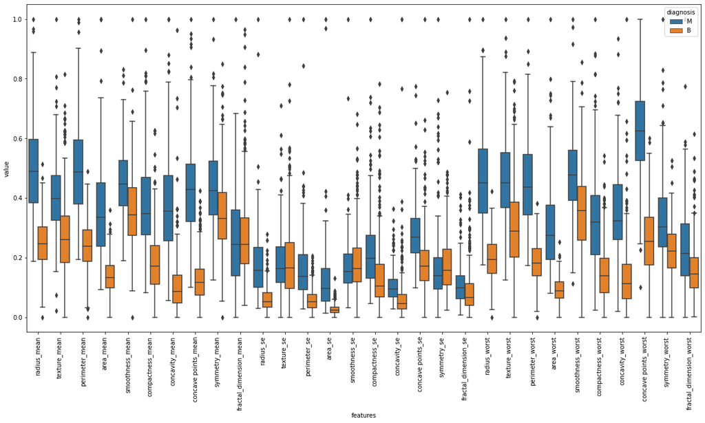

```python
data_melted = pd.melt(unlabeled_data_scaled, id_vars="diagnosis",
                    var_name="features",
                    value_name='value')
data_melted.head()
plt.figure(figsize=(20,10))
sns.boxplot(x="features", y="value", hue="diagnosis", data=data_melted)
plt.xticks(rotation=90)
```

The parameters considered critical would be those which most separate data. According to the distributions of the different variables, there are notable differences between the two types of class, malignant and benign. For example, for the attribute 'radius_worst', the mean of the malignant and benign nuclei seems to be separated, which may be useful for later classification techniques. In other cases, as in the 'texture_se' attribute, the mean for malignant and benign tumors does not seem to be separated and therefore is not informative for classification.

A correlation matrix was used to assess the quality of the features, and how relevant are these for the diagnosis of a sample as benign or malign. I the correlation plot below, highly correlated features are considered redundant and thus one of them can be selected as a group representative.

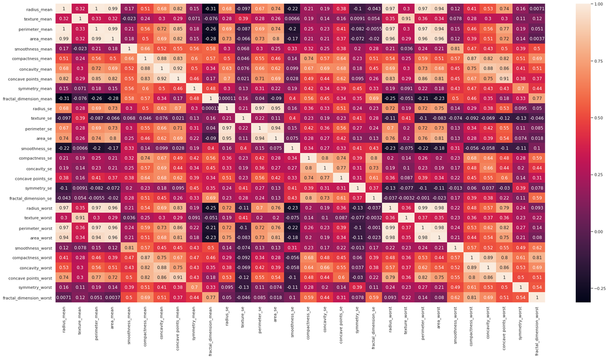

```python
corrMatrix = data.drop(['diagnosis'], axis=1).corr()
#print (corrMatrix)
sns.heatmap(corrMatrix, annot=True)
sns.set(rc={'figure.figsize':(30,15)})
plt.show()
```

Several groups of attributes are found to be correlated, which indicates that they could be dispensed:

- *compactness mean, concavity mean* and *concave points mean*
- *radius se, perimeter se* and *area se*
- *radius worst, perimeter worst* and *area worst*
- *compactness worst, concavity worst* and *concave points worst*
- *compactness se, concavity se* and *concave points se*
- *texture mean* and *texture worst*
- *area worst* and *area mean*

### 2.2 Data Cleansing

```python
import numpy as np # linear algebra
import pandas as pd # data processing, CSV file I/O (e.g. pd.read_csv)
import seaborn as sns # data visualization library
import matplotlib.pyplot as plt
#https://jupyterlab-9.labs.cognitiveclass.ai/hub/user-redirect/lab/tree/labs/User/Advanced%20IBM%20Data%20Science%20/Capstone/data.csv
```

```python
data_raw = pd.read_csv('data.csv')
data = data_raw.drop(['id', 'Unnamed: 32'], axis=1)
data.describe()
```

|  | radius_mean | texture_mean | perimeter_mean | area_mean | smoothness_mean | compactness_mean | concavity_mean | concave points_mean | symmetry_mean | fractal_dimension_mean | ... | radius_worst | texture_worst | perimeter_worst | area_worst | smoothness_worst | compactness_worst | concavity_worst | concave points_worst | symmetry_worst | fractal_dimension_worst |
| --- | --- | --- | --- | --- | --- | --- | --- | --- | --- | --- | --- | --- | --- | --- | --- | --- | --- | --- | --- | --- | --- |
| count | 569.000000 | 569.000000 | 569.000000 | 569.000000 | 569.000000 | 569.000000 | 569.000000 | 569.000000 | 569.000000 | 569.000000 | ... | 569.000000 | 569.000000 | 569.000000 | 569.000000 | 569.000000 | 569.000000 | 569.000000 | 569.000000 | 569.000000 | 569.000000 |
| mean | 14.127292 | 19.289649 | 91.969033 | 654.889104 | 0.096360 | 0.104341 | 0.088799 | 0.048919 | 0.181162 | 0.062798 | ... | 16.269190 | 25.677223 | 107.261213 | 880.583128 | 0.132369 | 0.254265 | 0.272188 | 0.114606 | 0.290076 | 0.083946 |
| std | 3.524049 | 4.301036 | 24.298981 | 351.914129 | 0.014064 | 0.052813 | 0.079720 | 0.038803 | 0.027414 | 0.007060 | ... | 4.833242 | 6.146258 | 33.602542 | 569.356993 | 0.022832 | 0.157336 | 0.208624 | 0.065732 | 0.061867 | 0.018061 |
| min | 6.981000 | 9.710000 | 43.790000 | 143.500000 | 0.052630 | 0.019380 | 0.000000 | 0.000000 | 0.106000 | 0.049960 | ... | 7.930000 | 12.020000 | 50.410000 | 185.200000 | 0.071170 | 0.027290 | 0.000000 | 0.000000 | 0.156500 | 0.055040 |
| 25% | 11.700000 | 16.170000 | 75.170000 | 420.300000 | 0.086370 | 0.064920 | 0.029560 | 0.020310 | 0.161900 | 0.057700 | ... | 13.010000 | 21.080000 | 84.110000 | 515.300000 | 0.116600 | 0.147200 | 0.114500 | 0.064930 | 0.250400 | 0.071460 |
| 50% | 13.370000 | 18.840000 | 86.240000 | 551.100000 | 0.095870 | 0.092630 | 0.061540 | 0.033500 | 0.179200 | 0.061540 | ... | 14.970000 | 25.410000 | 97.660000 | 686.500000 | 0.131300 | 0.211900 | 0.226700 | 0.099930 | 0.282200 | 0.080040 |
| 75% | 15.780000 | 21.800000 | 104.100000 | 782.700000 | 0.105300 | 0.130400 | 0.130700 | 0.074000 | 0.195700 | 0.066120 | ... | 18.790000 | 29.720000 | 125.400000 | 1084.000000 | 0.146000 | 0.339100 | 0.382900 | 0.161400 | 0.317900 | 0.092080 |
| max | 28.110000 | 39.280000 | 188.500000 | 2501.000000 | 0.163400 | 0.345400 | 0.426800 | 0.201200 | 0.304000 | 0.097440 | ... | 36.040000 | 49.540000 | 251.200000 | 4254.000000 | 0.222600 | 1.058000 | 1.252000 | 0.291000 | 0.663800 | 0.207500 |

8 rows × 30 columns

I converted the target column to categorical binary data.

```python
data['diagnosis'] = data['diagnosis'].astype('category')
data.dtypes
```

```
diagnosis                  category
radius_mean                 float64
texture_mean                float64
perimeter_mean              float64
area_mean                   float64
smoothness_mean             float64
compactness_mean            float64
concavity_mean              float64
concave points_mean         float64
symmetry_mean               float64
fractal_dimension_mean      float64
radius_se                   float64
texture_se                  float64
perimeter_se                float64
area_se                     float64
smoothness_se               float64
compactness_se              float64
concavity_se                float64
concave points_se           float64
symmetry_se                 float64
fractal_dimension_se        float64
radius_worst                float64
texture_worst               float64
perimeter_worst             float64
area_worst                  float64
smoothness_worst            float64
compactness_worst           float64
concavity_worst             float64
concave points_worst        float64
symmetry_worst              float64
fractal_dimension_worst     float64
dtype: object
```

```
(array([ 0,  1,  2,  3,  4,  5,  6,  7,  8,  9, 10, 11, 12, 13, 14, 15, 16,
        17, 18, 19, 20, 21, 22, 23, 24, 25, 26, 27, 28, 29]),
 [Text(0, 0, 'radius_mean'),
```

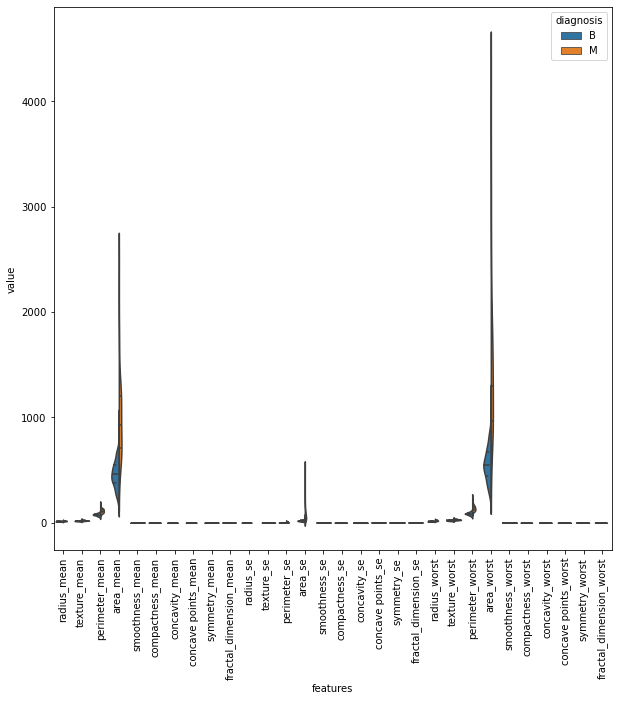

```python
dataviz = pd.melt(data,id_vars="diagnosis",
                    var_name="features",
                    value_name='value')
plt.figure(figsize=(10,10))
sns.violinplot(x="features", y="value", hue="diagnosis", data=dataviz,split=True, inner="quart")
plt.xticks(rotation=90)
```

In this case, features contain values in a wide variety of ranges. For this reason, normalization was performed.

```python
from sklearn import preprocessing
label = data.diagnosis
unlabeled_data = data.drop(['diagnosis'],axis = 1 )

x = unlabeled_data.values #returns a numpy array
min_max_scaler = preprocessing.MinMaxScaler()
x_scaled = min_max_scaler.fit_transform(x)
unlabeled_data_scaled = pd.DataFrame(x_scaled)
unlabeled_data_scaled.columns = unlabeled_data.columns
data_scaled = pd.concat([label, unlabeled_data_scaled], axis=1)
data_scaled.head()
```

|  | diagnosis | radius_mean | texture_mean | perimeter_mean | area_mean | smoothness_mean | compactness_mean | concavity_mean | concave points_mean | symmetry_mean | ... | radius_worst | texture_worst | perimeter_worst | area_worst | smoothness_worst | compactness_worst | concavity_worst | concave points_worst | symmetry_worst | fractal_dimension_worst |
| --- | --- | --- | --- | --- | --- | --- | --- | --- | --- | --- | --- | --- | --- | --- | --- | --- | --- | --- | --- | --- | --- |
| 0 | M | 0.521037 | 0.022658 | 0.545989 | 0.363733 | 0.593753 | 0.792037 | 0.703140 | 0.731113 | 0.686364 | ... | 0.620776 | 0.141525 | 0.668310 | 0.450698 | 0.601136 | 0.619292 | 0.568610 | 0.912027 | 0.598462 | 0.418864 |
| 1 | M | 0.643144 | 0.272574 | 0.615783 | 0.501591 | 0.289880 | 0.181768 | 0.203608 | 0.348757 | 0.379798 | ... | 0.606901 | 0.303571 | 0.539818 | 0.435214 | 0.347553 | 0.154563 | 0.192971 | 0.639175 | 0.233590 | 0.222878 |
| 2 | M | 0.601496 | 0.390260 | 0.595743 | 0.449417 | 0.514309 | 0.431017 | 0.462512 | 0.635686 | 0.509596 | ... | 0.556386 | 0.360075 | 0.508442 | 0.374508 | 0.483590 | 0.385375 | 0.359744 | 0.835052 | 0.403706 | 0.213433 |
| 3 | M | 0.210090 | 0.360839 | 0.233501 | 0.102906 | 0.811321 | 0.811361 | 0.565604 | 0.522863 | 0.776263 | ... | 0.248310 | 0.385928 | 0.241347 | 0.094008 | 0.915472 | 0.814012 | 0.548642 | 0.884880 | 1.000000 | 0.773711 |
| 4 | M | 0.629893 | 0.156578 | 0.630986 | 0.489290 | 0.430351 | 0.347893 | 0.463918 | 0.518390 | 0.378283 | ... | 0.519744 | 0.123934 | 0.506948 | 0.341575 | 0.437364 | 0.172415 | 0.319489 | 0.558419 | 0.157500 | 0.142595 |

5 rows × 31 columns

```
(array([ 0,  1,  2,  3,  4,  5,  6,  7,  8,  9, 10, 11, 12, 13, 14, 15, 16,
        17, 18, 19, 20, 21, 22, 23, 24, 25, 26, 27, 28, 29]),
 [Text(0, 0, 'radius_mean'),
```

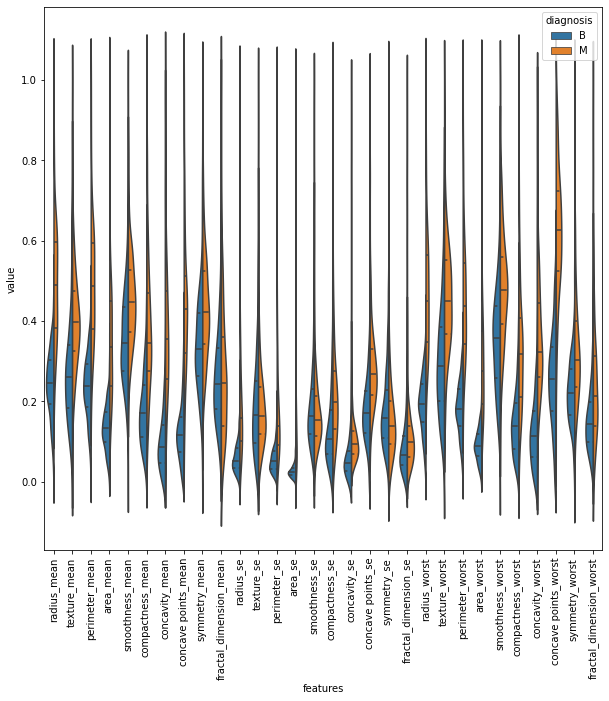

```python
dataviz = pd.melt(data_scaled,id_vars="diagnosis",
                    var_name="features",
                    value_name='value')
plt.figure(figsize=(10,10))
sns.violinplot(x="features", y="value", hue="diagnosis", data=dataviz,split=True, inner="quart")
plt.xticks(rotation=90)
```

#### Outliers detection

For the identification of outliers, Z-score was used. The term Z-score, standardized unit, reduced center variable, standardized or normalized variable is used in statistics to compare data from different samples or populations and is defined as the number of standard deviations that a given value takes from the mean of its sample or population.

For each feature, Z-score is computed, relative to that column mean and sd. Then, the absolute of Z-score is taken because the sign does not matter, only if it's below the threshold. Then it is applied to every element in a row.

```python
data_scaled.shape
```

```
(569, 31)
```

```python
from scipy import stats
data_scaled_o = data_scaled[(np.abs(stats.zscore(data_scaled.iloc[:,1:31])) < 3).all(axis=1)]
data_scaled_o.shape
```

```
(495, 31)
```

We have herby removed 74 samples that could be considered outliers for some of the studied features.

```python
data_scaled_o.to_csv("cleansed_data.csv")
```

### 2.3 Feature Engineering

Already in the initial data exploration, the correlation between features was observed. Let's compute it again for our cleansed dataset.

```python
import pandas as pd

data = pd.read_csv('cleansed_data.csv')
data = data.drop(['Unnamed: 0'], axis=1)
data.head()
```

|  | diagnosis | radius_mean | texture_mean | perimeter_mean | area_mean | smoothness_mean | compactness_mean | concavity_mean | concave points_mean | symmetry_mean | ... | radius_worst | texture_worst | perimeter_worst | area_worst | smoothness_worst | compactness_worst | concavity_worst | concave points_worst | symmetry_worst | fractal_dimension_worst |
| --- | --- | --- | --- | --- | --- | --- | --- | --- | --- | --- | --- | --- | --- | --- | --- | --- | --- | --- | --- | --- | --- |
| 0 | M | 0.643144 | 0.272574 | 0.615783 | 0.501591 | 0.289880 | 0.181768 | 0.203608 | 0.348757 | 0.379798 | ... | 0.606901 | 0.303571 | 0.539818 | 0.435214 | 0.347553 | 0.154563 | 0.192971 | 0.639175 | 0.233590 | 0.222878 |
| 1 | M | 0.601496 | 0.390260 | 0.595743 | 0.449417 | 0.514309 | 0.431017 | 0.462512 | 0.635686 | 0.509596 | ... | 0.556386 | 0.360075 | 0.508442 | 0.374508 | 0.483590 | 0.385375 | 0.359744 | 0.835052 | 0.403706 | 0.213433 |
| 2 | M | 0.629893 | 0.156578 | 0.630986 | 0.489290 | 0.430351 | 0.347893 | 0.463918 | 0.518390 | 0.378283 | ... | 0.519744 | 0.123934 | 0.506948 | 0.341575 | 0.437364 | 0.172415 | 0.319489 | 0.558419 | 0.157500 | 0.142595 |
| 3 | M | 0.258839 | 0.202570 | 0.267984 | 0.141506 | 0.678613 | 0.461996 | 0.369728 | 0.402038 | 0.518687 | ... | 0.268232 | 0.312633 | 0.263908 | 0.136748 | 0.712739 | 0.482784 | 0.427716 | 0.598282 | 0.477035 | 0.454939 |
| 4 | M | 0.533343 | 0.347311 | 0.523875 | 0.380276 | 0.379164 | 0.274891 | 0.264058 | 0.367793 | 0.370707 | ... | 0.531839 | 0.416844 | 0.511928 | 0.349194 | 0.482269 | 0.223448 | 0.302236 | 0.663918 | 0.295289 | 0.187853 |

5 rows × 31 columns

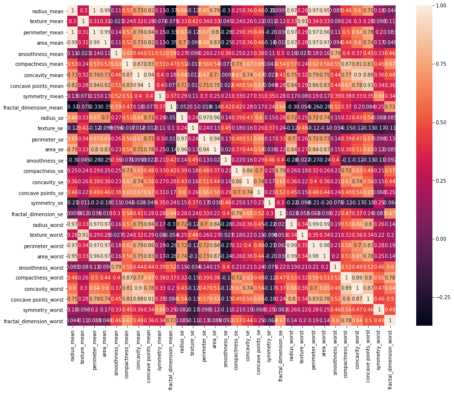

```python
import seaborn as sns
import matplotlib.pyplot as plt

corr_matrix = data.drop(['diagnosis'], axis=1).corr()
plt.subplots(figsize=(15,12))
sns.heatmap(corr_matrix, annot=True)
plt.show()
```

From here we learn that there are groups of correlated features:

```python
data.columns
```

```
Index(['diagnosis', 'radius_mean', 'texture_mean', 'perimeter_mean',
       'area_mean', 'smoothness_mean', 'compactness_mean', 'concavity_mean',
       'concave points_mean', 'symmetry_mean', 'fractal_dimension_mean',
       'radius_se', 'texture_se', 'perimeter_se', 'area_se', 'smoothness_se',
       'compactness_se', 'concavity_se', 'concave points_se', 'symmetry_se',
       'fractal_dimension_se', 'radius_worst', 'texture_worst',
       'perimeter_worst', 'area_worst', 'smoothness_worst',
       'compactness_worst', 'concavity_worst', 'concave points_worst',
       'symmetry_worst', 'fractal_dimension_worst'],
      dtype='object')
```

```python
droplist = ['compactness_mean', 'concavity_mean', 'radius_se', 'perimeter_se',
           'radius_worst', 'perimeter_worst', 'area_worst', 'compactness_worst',
           'concavity_worst', 'compactness_se', 'concavity_se',
           'texture_mean','area_worst', 'radius_mean', 'perimeter_mean', 'concave points_worst']
data_filt = data.drop(droplist, axis=1)
data_filt.head()
```

|  | diagnosis | area_mean | smoothness_mean | concave points_mean | symmetry_mean | fractal_dimension_mean | texture_se | area_se | smoothness_se | concave points_se | symmetry_se | fractal_dimension_se | texture_worst | smoothness_worst | symmetry_worst | fractal_dimension_worst |
| --- | --- | --- | --- | --- | --- | --- | --- | --- | --- | --- | --- | --- | --- | --- | --- | --- |
| 0 | M | 0.501591 | 0.289880 | 0.348757 | 0.379798 | 0.141323 | 0.082589 | 0.125660 | 0.119387 | 0.253836 | 0.084539 | 0.091110 | 0.303571 | 0.347553 | 0.233590 | 0.222878 |
| 1 | M | 0.449417 | 0.514309 | 0.635686 | 0.509596 | 0.211247 | 0.094303 | 0.162922 | 0.150831 | 0.389847 | 0.205690 | 0.127006 | 0.360075 | 0.483590 | 0.403706 | 0.213433 |
| 2 | M | 0.489290 | 0.430351 | 0.518390 | 0.378283 | 0.186816 | 0.093065 | 0.163688 | 0.332359 | 0.357075 | 0.136179 | 0.145800 | 0.123934 | 0.437364 | 0.157500 | 0.142595 |
| 3 | M | 0.141506 | 0.678613 | 0.402038 | 0.518687 | 0.551179 | 0.117132 | 0.038080 | 0.197063 | 0.215382 | 0.193730 | 0.144660 | 0.312633 | 0.712739 | 0.477035 | 0.454939 |
| 4 | M | 0.380276 | 0.379164 | 0.367793 | 0.370707 | 0.157119 | 0.091275 | 0.087987 | 0.088418 | 0.196818 | 0.081725 | 0.044367 | 0.416844 | 0.482269 | 0.295289 | 0.187853 |

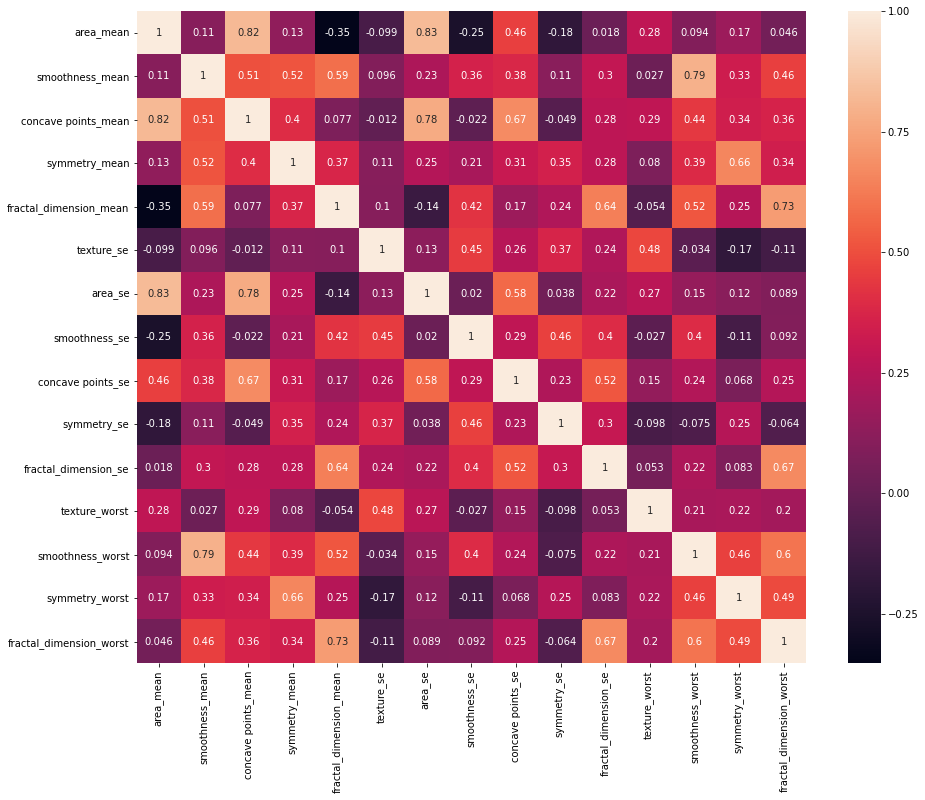

```python
corr_matrix = data_filt.drop(['diagnosis'], axis=1).corr()
plt.subplots(figsize=(15,12))
sns.heatmap(corr_matrix, annot=True)
plt.show()
```

The selected features are:

```python
data_filt.columns
```

```
Index(['diagnosis', 'area_mean', 'smoothness_mean', 'concave points_mean',
       'symmetry_mean', 'fractal_dimension_mean', 'texture_se', 'area_se',
       'smoothness_se', 'concave points_se', 'symmetry_se',
       'fractal_dimension_se', 'texture_worst', 'smoothness_worst',
       'symmetry_worst', 'fractal_dimension_worst'],
      dtype='object')
```

```python
data_filt.to_csv("cleansed_featEng_data.csv")
```

### 2.4 Model Definition and Training

Import the dataframe from the previous step. Split the data into train and test.

```python
import pandas as pd

data = pd.read_csv('cleansed_featEng_data.csv')
data = data.drop(['Unnamed: 0'], axis=1)
data.head()
```

|  | diagnosis | area_mean | smoothness_mean | concave points_mean | symmetry_mean | fractal_dimension_mean | texture_se | area_se | smoothness_se | concave points_se | symmetry_se | fractal_dimension_se | texture_worst | smoothness_worst | symmetry_worst | fractal_dimension_worst |
| --- | --- | --- | --- | --- | --- | --- | --- | --- | --- | --- | --- | --- | --- | --- | --- | --- |
| 0 | M | 0.501591 | 0.289880 | 0.348757 | 0.379798 | 0.141323 | 0.082589 | 0.125660 | 0.119387 | 0.253836 | 0.084539 | 0.091110 | 0.303571 | 0.347553 | 0.233590 | 0.222878 |
| 1 | M | 0.449417 | 0.514309 | 0.635686 | 0.509596 | 0.211247 | 0.094303 | 0.162922 | 0.150831 | 0.389847 | 0.205690 | 0.127006 | 0.360075 | 0.483590 | 0.403706 | 0.213433 |
| 2 | M | 0.489290 | 0.430351 | 0.518390 | 0.378283 | 0.186816 | 0.093065 | 0.163688 | 0.332359 | 0.357075 | 0.136179 | 0.145800 | 0.123934 | 0.437364 | 0.157500 | 0.142595 |
| 3 | M | 0.141506 | 0.678613 | 0.402038 | 0.518687 | 0.551179 | 0.117132 | 0.038080 | 0.197063 | 0.215382 | 0.193730 | 0.144660 | 0.312633 | 0.712739 | 0.477035 | 0.454939 |
| 4 | M | 0.380276 | 0.379164 | 0.367793 | 0.370707 | 0.157119 | 0.091275 | 0.087987 | 0.088418 | 0.196818 | 0.081725 | 0.044367 | 0.416844 | 0.482269 | 0.295289 | 0.187853 |

```python
X = data.drop(['diagnosis'], axis=1)
y = data.diagnosis
```

```python
import numpy as np
from sklearn.model_selection import train_test_split

X_train, X_test, y_train, y_test = train_test_split(X, y, test_size=0.33, random_state=42)
```

In this case, we built two baseline ML models that were reviewed in the previous courses in this specialization diploma: Random Forest and Support Vector Machines (SVM). The chosen metric for model evaluation was the accuracy. Besides, confusion matrices were reoconstructed for better visualization of the results.

#### Random Forest Classification

|  | Method | Accuracy |
| --- | --- | --- |
| 0 | Random Forest | 0.996979 |

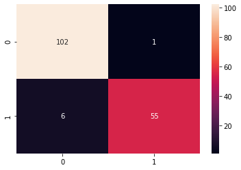

```python
from sklearn.model_selection import train_test_split
from sklearn.ensemble import RandomForestClassifier
from sklearn.metrics import f1_score,confusion_matrix
from sklearn.metrics import accuracy_score
import seaborn as sns

#random forest classifier with n_estimators=10 (default)
clf_rf = RandomForestClassifier(random_state=43)
clr_rf = clf_rf.fit(X_train,y_train)

ac = accuracy_score(y_train,clf_rf.predict(X_train))
methods = pd.DataFrame({'Method': ['Random Forest'], 'Accuracy': [ac]})
cm = confusion_matrix(y_test,clf_rf.predict(X_test))
sns.heatmap(cm,annot=True,fmt="d")
methods.head()
```

#### SVM

|  | Method | Accuracy |
| --- | --- | --- |
| 0 | Random Forest | 0.996979 |
| 1 | SVM | 0.884146 |

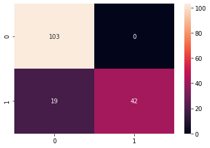

```python
from sklearn import svm
from sklearn import metrics

model = svm.SVC()
model.fit(X_train,y_train)
prediction=model.predict(X_test)
metrics.accuracy_score(prediction,y_test)

ac = accuracy_score(y_test,model.predict(X_test))
methods = methods.append({'Method': 'SVM', 'Accuracy': ac}, ignore_index=True)
cm = confusion_matrix(y_test,model.predict(X_test))
sns.heatmap(cm,annot=True,fmt="d")
methods
```

## 3. Discussion

Since the initial diagnostic data set was generated in order to discriminate between two specific classes of tumors, supervised learning techniques would be the most appropriate for its analysis.

Feature engineering identified the following 15 key features:

1. 'area_mean'
2. 'smoothness_mean'
3. 'concave points_mean'
4. 'symmetry_mean'
5. 'fractal_dimension_mean'
6. 'texture_se'
7. 'area_se'
8. 'smoothness_se'
9. 'concave points_se'
10. 'symmetry_se'
11. 'fractal_dimension_se'
12. 'texture_worst'
13. 'smoothness_worst'
14. 'symmetry_worst'
15. 'fractal_dimension_worst'

In a remarkable way, the diagnostic potential of the methodology proposed in this work can be easily extrapolated to other types of tumors, since the physiopathological characteristics of the tumor tissue involve a mesenchymal cell architecture, common to most tumors. This is due to the fact that tumour cells tend to go through a previous stage of differentiation with great proliferative capacity. It is therefore common to find in these cells characteristics that allow establishing a demarcation criterion with respect to the rest of the cells in their environment, such as the fragmented nucleus, the formation of syncites or the loss of cellular adhesion. In this sense, artificial intelligence techniques could assist and support biomedical research.